# Ecological Models and Data Analysis – Chapter 4, Lecture 1 — Ecological Models and Data Analysis

## Ecological Models and Data Analysis

Chapter 4 · Lecture 1

Maximum Likelihood Estimation: the Method

## Overview of the lecture

1. **The likelihood:** how probable are the data for a given parameter value?
2. **The log-likelihood:** why do we work with logarithms?
3. **Maximum likelihood estimation:** which value is best supported?
4. **The fit in R:** how do we find it numerically?
5. **Transformations:** how do we keep a parameter within its range?
6. **Several parameters:** what does the likelihood say about one of them?
7. **A profile in R:** how does TMB calculate one?
8. **The practical:** what do we try next?

## From the method of moments to maximum likelihood

### Method of moments

Uses the mean and the variance of a sample.

### Maximum likelihood

Uses the probability of every observation. Works for any model with a mass or density function.

Two running examples: fir seedlings in 50 quadrats (Poisson); barn owl calls at 122 visits (Negative Binomial).

Same concepts (estimator, sampling distribution, standard error, confidence interval), a different estimator: the method of the rest of the course.

## The likelihood function

**Likelihood:** the joint probability of the observed sample, read as a function of the parameters with the data held fixed.

$$L(\theta\mid x_1,\ldots,x_n)
= P(X_1=x_1,\ldots,X_n=x_n\mid\theta)
= \prod_{i=1}^{n}P(X_i=x_i\mid\theta)$$

- **The bar:** reads “for a given value of”.
- **The product:** comes from independence.
- **Continuous data:** densities replace probabilities.

Fir seedlings: $X_i \sim \operatorname{Poisson}(\lambda)$, with $x_i$ the seedlings in quadrat $i$.

## Probability and likelihood

### Probability

Parameters fixed, data vary (Chapter 2).

### Likelihood

Data fixed, parameters vary.

The Poisson mass $e^{-\lambda}\lambda^{x}/x!$: a function of $x$ for a fixed $\lambda$, or a function of $\lambda$ for an observed $x$.

A parameter value under which the sample is more probable is better supported by the data.

## Probability mass and likelihood curve

### Probability

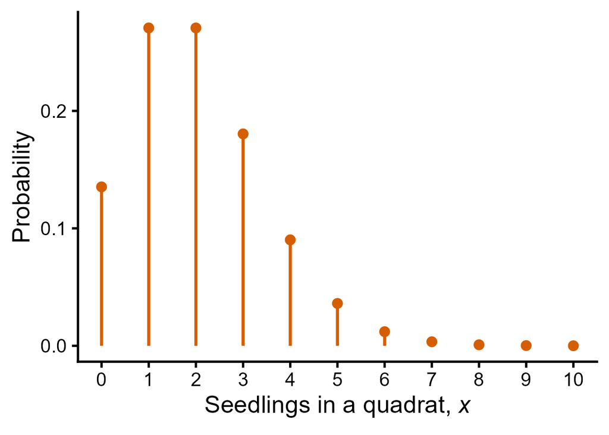

$\lambda$ fixed, the count $x$ varies

### Likelihood

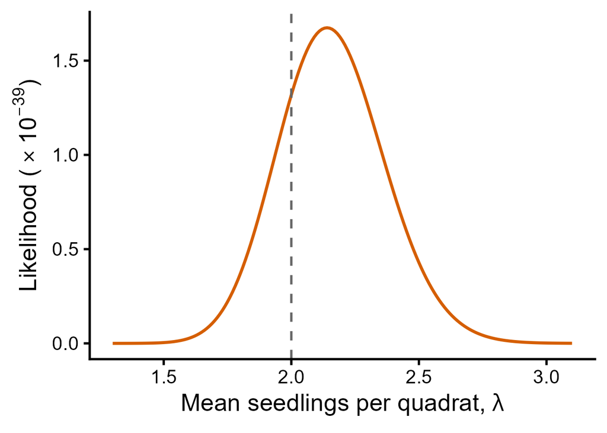

The observed counts fixed, $\lambda$ varies

Left: Poisson probabilities for $\lambda=2$. Right: likelihood of the 50 fir quadrats; dashed: $\lambda=2$.

## A likelihood by hand

First three quadrats (0, 1 and 2 seedlings):

$$L(\lambda\mid 0,1,2)
= \frac{e^{-\lambda}\lambda^{0}}{0!}\times
\frac{e^{-\lambda}\lambda^{1}}{1!}\times
\frac{e^{-\lambda}\lambda^{2}}{2!}
= \frac{e^{-3\lambda}\lambda^{3}}{2}$$

0.0249 at $\lambda=1$ and 0.0099 at $\lambda=2$: about 2.5 times more probable under a mean of 1.

- **Each observation:** contributes its probability.
- **The contributions:** are multiplied.
- **Two parameter values:** compared by the ratio of their likelihoods, how many times more probable the sample is under one than under the other.
- **Its value:** means nothing by itself; only comparisons for the same data.

## A likelihood is not the probability of a parameter value

- **The parameter:** fixed in the model.
- **Probabilities:** describe data and estimates across hypothetical samples.
- **Over parameter values:** a likelihood need not add up or integrate to one.

50 quadrats: the area under the likelihood is about $8.7\times10^{-40}$.

Use a likelihood to compare parameter values.

## Discussion: probability or likelihood?

1. How probable are three seedlings in a quadrat at $\lambda=2$?
2. How well do the counts 0, 1 and 2 support $\lambda=1$ against $\lambda=2$?
3. A quantity that sums to one over all possible counts.
4. A curve whose area is $8.7\times10^{-40}$.

Probability · Likelihood

**1 minute:** decide with a neighbour.

## The log-likelihood

$$\ell(\theta) = \log(L(\theta)) = \sum_{i=1}^{n}\log(P(X_i=x_i\mid\theta))$$

- **The product:** becomes a sum.
- **The logarithm:** is increasing, so the maximum is at the same value.
- **Products of many probabilities:** fall below what the computer can represent.
- **Continuous data:** densities have units, so a log-likelihood can be positive and changes with the units; differences do not.

1,000 simulated counts with $\lambda=4$: `prod()` returns 0; the sum of the log probabilities is $-2094.6$.

## Log-likelihoods in R

- **`log = TRUE`:** an argument of every `d*` function.
- **More accurate:** than taking the logarithm afterwards.
- **The log-likelihood:** the sum of these values.

```r
# Counts of balsam fir seedlings in 50 quadrats (see ?boot::fir).
data(fir, package = "boot")
seedling_counts = fir$count

# Log-likelihood at lambda = 2: about -89.52.
sum(dpois(x = seedling_counts, lambda = 2, log = TRUE))

# The same number, from the logarithm of the product.
log(prod(dpois(x = seedling_counts, lambda = 2)))
```

## Practice 1: crab burrows

**3 minutes:** on paper.

Three plots on a mudflat contain 3, 1 and 2 crab burrows; the counts are i.i.d. Poisson.

1. Write the likelihood as a function of $\lambda$.
2. Calculate the likelihood and the log-likelihood at $\lambda=2$ and at $\lambda=3$ burrows per plot.
3. Which of the two values is better supported by the data?

## The maximum likelihood estimator

**Maximum likelihood estimator (MLE):** the value of the parameter for which the likelihood of the observed sample is highest.

$$\hat\theta
= \underset{\theta}{\arg\max}\;L(\theta\mid x_1,\ldots,x_n)
= \underset{\theta}{\arg\max}\;\ell(\theta\mid x_1,\ldots,x_n)$$

- **$\arg\max$:** the location of the maximum; $\max$ gives its height.
- **MLE:** stands for both the estimator and the estimate.
- **Closed form:** the slope of $\ell$ is zero at the maximum; solving for it works for only a few models, so in general we search numerically.

Poisson: $\hat\lambda=\overline x$, 2.14 seedlings per quadrat, which is also the method-of-moments estimate.

## The likelihood curve

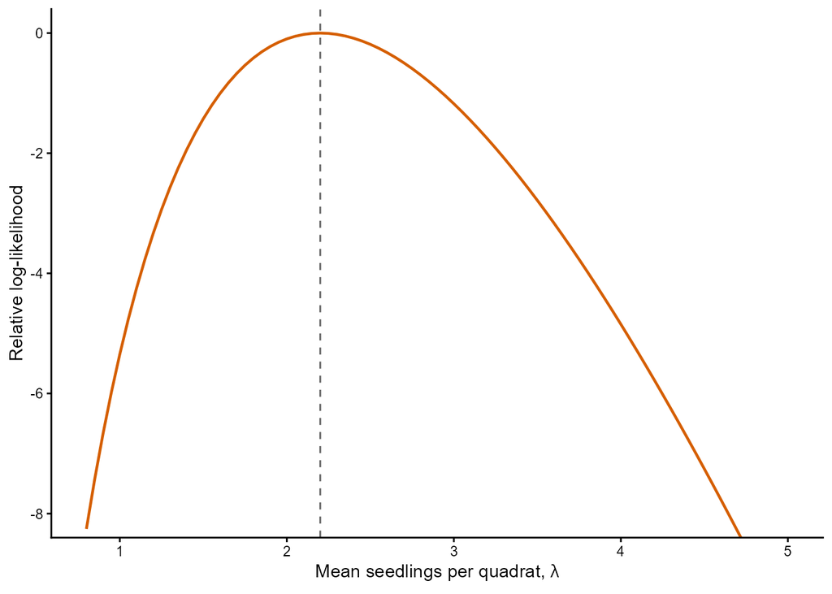

$$\ell(\theta)-\ell(\hat\theta)$$

- **Relative log-likelihood:** zero at the estimate, negative elsewhere.
- **This scale:** only differences have meaning.
- **How fast it falls:** how well the data discriminate.
- **Shape:** need not be symmetric.

First ten quadrats (22 seedlings): $\hat\lambda=2.2$; $-3.33$ at 1.2 and $-1.76$ at 3.2.

Vermillion: relative log-likelihood. Dashed: the estimate.

## Numerical optimisation

**Optimiser:** searches for the values at which a function reaches its minimum.

[figure not shown]

- **Starts** from values that we provide.
- **Moves** step by step to lower values.
- **Stops** when it cannot improve.
- **`optim()` minimises:** we give it the **negative log-likelihood** (NLL), $-\ell(\theta)$.

## The negative log-likelihood in R

- **A function of two named lists:** `parms` and `data`.
- **`getAll()`:** makes their elements available by name.
- **Returns:** minus the sum of the log probabilities.

```r
# Negative log-likelihood of Poisson counts. The first argument holds the parameters
# and the second the data, both as named lists.
poisson_nll_lambda = function(parms, data) {
  # Make the elements of both lists available by name.
  getAll(parms, data)
  -sum(dpois(x = counts, lambda = lambda, log = TRUE))
}
```

This is the form of every NLL in the course.

## From the negative log-likelihood to a fit

[figure not shown]

- **`cmb()`:** connects a likelihood to a data set; works again on other data with the same names.
- **`MakeADFun()`:** processes the NLL for the tools of the course, and takes the starting values.
- **`par`, `fn`, `gr`:** the starting values, the NLL and its gradients.
- **`optim()`:** minimises `fn` from `par`, using `gr`.

## A fit in R

The same three steps for every model:

```r
# Step 1: connect a likelihood to a data set.
cmb = function(f, d) function(p) f(p, d)

# Step 2: process the NLL of the 50 counts, with a starting value of 1 seedling per quadrat.
fir_lambda_obj = MakeADFun(
  cmb(poisson_nll_lambda, list(counts = seedling_counts)),
  list(lambda = 1),
  silent = TRUE
)

# Step 3: minimise fn, starting from par and using the slope gr.
fir_lambda_fit = optim(
  par = fir_lambda_obj$par,
  fn = fir_lambda_obj$fn,
  gr = fir_lambda_obj$gr,
  method = "BFGS"
)
```

## The result of `optim()`

- **`par`:** the estimates.
- **`value`:** the NLL at the estimates.
- **`convergence`:** zero when the search stopped normally; the first thing to check.
- **A code other than zero:** `par` holds no estimates.

```r
fir_lambda_fit$par          # 2.14 seedlings per quadrat
fir_lambda_fit$value        # NLL at the estimate
fir_lambda_fit$convergence  # 0: a normal stop
```

## Constraints and transformations

**Constraint:** a restriction on the values that a parameter can take.

- **An optimiser:** can try any real number; an impossible value gives `NaN`.
- **Transformation:** the search is over a quantity that can be any real number, and the NLL converts it.
- **Positive parameter:** logarithm, with `exp()` back.
- **Probability:** logit, with `qlogis()` and `plogis()`.

```r
poisson_nll = function(parms, data) {
  getAll(parms, data)
  # Transform the parameter to the original scale.
  lambda = exp(log_lambda)
  -sum(dpois(x = counts, lambda = lambda, log = TRUE))
}
# After the fit, as before: 2.14 seedlings per quadrat.
exp(fir_fit$par)
```

## Invariance

$$\widehat{g(\theta)} = g(\hat\theta)$$

- **Invariance:** the MLE of a function of a parameter is that function of the MLE.
- **The reason:** a transformation only relabels the axis of the likelihood curve, so the highest point is the same on both scales.
- **Other quantities:** the MLE of anything calculated from the parameter follows.

Probability of an empty quadrat: $e^{-\hat\lambda}\approx 0.12$ (7 of the 50 quadrats in the sample). Chapter 3 showed that this estimator is biased.

Invariance carries over the estimate and not unbiasedness.

## Practice 2: back to the ecological scale

**2 minutes:** R as a calculator.

A colleague fits two models with `optim()`:

- the logarithm of the mean number of ticks per lizard, with result `par = 0.92`;
- the logit of the probability that a seed germinates, with result `par = -0.85`.

Report both estimates on the ecological scale. Are they the maximum likelihood estimates of the mean and of the probability?

## Models with several parameters

- **The likelihood:** a function of all parameters jointly.
- **The MLE:** the combination with the highest likelihood.
- **The curve:** becomes a surface.
- **New questions:** how to look at it, how the estimates depend on each other, what the data say about one parameter.

Barn owls: 122 visits, mean 4.75 calls per visit, variance 42.3.

$$X_i \sim \operatorname{NegBin}(\mu,k),
\qquad \operatorname{Var}(X_i)=\mu+\frac{\mu^2}{k}$$

## A fit with two parameters in R

- **One list element** per parameter.
- **Every constrained parameter:** transformed.
- **Starting values:** from the method of moments.

```r
# dnbinom2() of RTMBdist takes mu and size.
nb_nll = function(parms, data) {
  getAll(parms, data)
  mu = exp(log_mu)
  k = exp(log_k)
  -sum(dnbinom2(x = calls, mu = mu, size = k, log = TRUE))
}
owl_obj = MakeADFun(
  cmb(nb_nll, list(calls = call_counts)),
  list(log_mu = log(mu_mom), log_k = log(k_mom)),
  silent = TRUE
)
owl_fit = optim(
  par = owl_obj$par, fn = owl_obj$fn,
  gr = owl_obj$gr, method = "BFGS"
)
# mu: about 4.75 calls per visit.
# k: about 0.33 (0.60 by the method of moments).
exp(owl_fit$par)
```

## Checking the fitted model

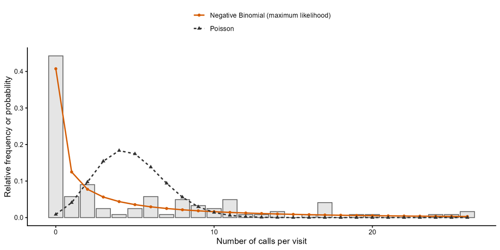

- **`optim()`:** returns estimates for any model, so we compare the fit with the data.
- **For counts:** relative frequencies against fitted probabilities.
- **Reference:** a simpler model.

Bars: the sample. Lines and points: the fitted models.

Zero calls: 44% of visits, 41% Negative Binomial, 0.9% Poisson. The log-likelihood is about 335 units higher.

## The likelihood surface

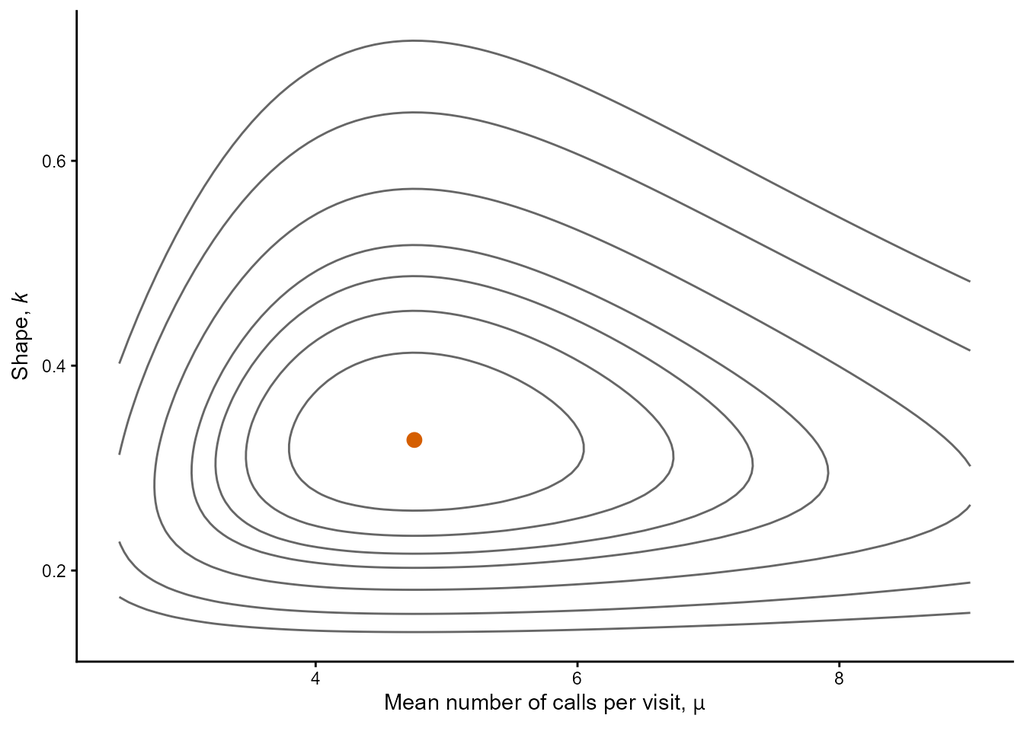

- **Contours:** join combinations with the same relative log-likelihood.
- **The MLE:** the top of the hill.
- **Contours not tilted:** the estimates hardly depend on each other.

$\mu$ and $k$: the best $\mu$ is the sample mean for every $k$.

Grey: contours of the relative log-likelihood. Vermillion circle: the MLE.

## Parameterisation

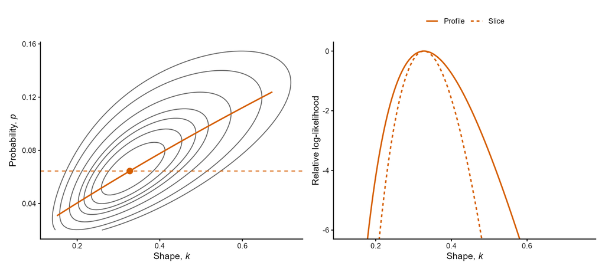

Left: contours in $k$ and $p$ (the lines are explained on the next slides). Right: the two curves of “Slice against profile”.

**Parameterisation:** the same model written with different parameters.

Shape $k$ and $p=k/(k+\mu)$: maximum $-299.44$ in both; $\hat p\approx0.064$; a larger $k$ goes with a larger $p$.

- **Same:** maximum and fitted model.
- **Different:** shape of the surface, which also matters for the optimiser (Chapter 8).
- **Tilted contours:** estimates that depend on each other.
- **In this course:** the mean where possible, because later models let it change with covariates.

## Slices and profiles

**Slice:** fix the other parameters, normally at their estimates.

**Profile:** re-estimate them for every value of the parameter of interest.

$$\ell_{\mathrm{prof}}(\theta_1)=\max_{\theta_2}\,\ell(\theta_1,\theta_2)$$

Shape $k$ and probability $p$: $\ell(k,\hat p)$ is a slice; $\max_p\,\ell(k,p)$ is the profile of $k$.

## Slice against profile

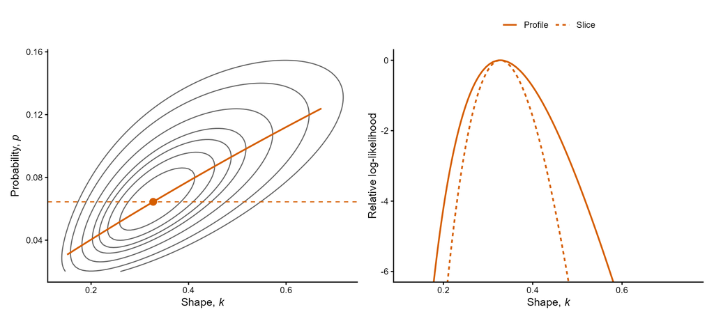

Left: contours with the slice (dashed) and the ridge (solid). Right: the two curves.

$k$ within 1.92 units: slice 0.26 to 0.41, profile 0.24 to 0.45.

## Live demo: a likelihood profile in R

1. **The fit:** a parameterisation with tilted contours; the same maximum.
2. **A slice:** the other parameter fixed at its estimate.
3. **The profile:** `TMB::tmbprofile()` re-estimates the other parameter at every value.
4. **Both curves:** relative log-likelihood of the slice and of the profile.

**Script:** `demo-profile.R` (the owl model with $k$ and $p$; it draws the right panel of “Slice against profile”).

## The Chapter 4 R practical: first part

- **Reed frog tadpoles** (Exercise 1, questions 1 to 3): likelihood by hand, estimator, fit; worked on the page.
- **Glacier lily seedlings** (Exercise 2, questions 1 to 3): method of moments, fit, contours.

Leave standard errors and the joint region for after Lecture 2. Try, then check.

## Summary and closing questions

- The likelihood is the probability of the sample, read as a function of the parameters.
- The log-likelihood is a sum, and only differences have meaning.
- The MLE is the value with the highest likelihood, found with `optim()`.
- Transformations keep parameters in range, and invariance carries the estimate back.
- Several parameters: a surface whose shape depends on the parameterisation.
- Slices fix the other parameters; profiles re-estimate them, and `TMB::tmbprofile()` calculates them for us.

Likelihood · Log-likelihood · MLE · NLL · Transformation · Invariance · Surface · Profile

**Closing questions**

1. Why is a likelihood not the probability of a parameter value?
2. Why is a slice narrower than a profile?